# Trabajo final. Modelos de regresion robustos

Vicente S. Mora

18 de diciembre de 2023

```r
require("data.table")
require("tidyverse")
require("tidymodels")
require("GGally")
require("corrr")
require("MASS")
require("lubridate")
require("caret")
require("lmtest")
require("gridExtra")

path <- "C:/Users/Vicente Mora/Desktop/Maestria/EEA/trabajo_final"
setwd(path)
```

# Introducción.

La confianza en las instituciones gubernamentales es uno de los temas de mayor interés para la sociedad. Por este motivo, el gobierno de Brasil hizo disponibles varios conjuntos de datos y APIs que permiten analizar la actividad de distintos miembros de las instituciones legislativas. Esto es parte de una iniciativa para promover la transparencia y aumentar la credibilidad en las instituciones estadales.

En particular, en el presente trabajo se hizo foco en un dataset que registra las solicitudes de reembolso emitidas por miembros de la cámara de diputados de Brasil. La intención es realizar un análisis predictivo de los consumos mensuales de los diputados usando las solicitudes de reembolso, ajustando modelos de regresión robustos. Se escogió esta herramienta por la posible presencia de valores atípicos en la variable a predecir. El análisis se realizó en términos de las características del diputado, su afiliación política, género, edad de los diputados y los montos de solicitudes de reembolso emitidas previamente.

# Objetivos.

El análisis realizado tiene los siguientes objetivos:

- Elaborar un modelo predictivo para los consumos mensuales de los miembros de la Cámara de Diputados de Brasil utilizando distintos modelos de regresión. Estos son: el modelo lineal simple, el modelo lineal múltiple y el modelo robusto.
- Establecer una guía de como aplicar los modelos de regresión robustos y evaluar el cumplimiento de los supuestos de los modelos, intentando mostrar como el uso de los M-estimadores (particularmente la función de pesos de Huber) influye en el ajuste.
- Comparar las métricas de performance entre los modelos realizados.

# Metodología.

Como primera aproximación, empezamos por realizar un preprocesamiento de los datos donde enriquecemos el dataset a utilizar con información pertinente a las características de los diputados: cuanto tiempo llevan ejerciendo, a que partido político pertenece, qué edad y sexo tienen, partido e ideología política, entre otros. Una vez realizado el preprocesamiento y enriquecimiento, empezamos con el análisis exploratorio para decidir qué variables pueden resultar útiles en la construcción del modelo, visualizar outliers y determinar si necesitamos hacer limpieza de alguna de las variables.

Luego del análisis exploratorio, empezamos con la construcción de los modelos. Se generará un modelo lineal simple y uno múltiple. Se evaluarán los supuestos del modelo lineal múltiple generado y determinaremos si hace falta utilizar un modelo robusto. De ser así, se ajustará un modelo robusto y procederemos a comparar métricas entre los modelos generados. Como parte del análisis, también se pretende realizar una breve interpretación de los modelos generados y los coeficientes resultantes.

### Preprocesamiento.

El conjunto de datos utilizado fue generado de la unión de varias fuentes externas:

- El archivo “dirty_deputies_v2.csv” es un dataset que registra los reembolsos solicitados por miembros de la cámara de diputados de Brasil en el periodo comprendido entre 2015-2017. El mismo consta de 339089 registros y 23 variables, de las cuales la mayoría son categóricas de alta cardinalidad. En total, se reportan los gastos de 584 diputados afiliados a distintos partidos que hacen vida en el panorama político brasileño. El dataset se encuentra disponible en: https://www.kaggle.com/datasets/epattaro/brazils-house-of-deputies-reimbursements/code
- El archivo “deputies_dataset.csv” es un dataset que también registra los reembolsos solicitados por miembros de la cámara de diputados de Brasil en el periodo comprendido entre 2009-2017. El mismo consta de 3014902 registros y 10 variables, de las cuales la mayoría son categóricas de alta cardinalidad. Es un dataset bastante parecido al primero, con la diferencia que es más limitado en términos de la información de partidos politicos que dispone, y tiene mayor cantidad de registros. Se encuentra disponible en: https://www.kaggle.com/datasets/epattaro/brazils-house-of-deputies-reimbursements/code
- El archivo “deputados.csv” es un dataset que registra todos los diputados que en algún momento formaron parte - o que hacen vida actualmente - en la cámara de diputados de Brasil. El mismo cuenta con 7826 registros y 13 variables. El dataset se encuentra disponible en: https://dadosabertos.camara.leg.br/swagger/api.html#staticfile
- El archivo “legislaturas.csv” es un dataset que registra todas las fechas de inicio y fin de las distintas legislaturas celebradas en la cámara de diputados. Una legislatura es un periodo en el cual los diputados electos ejercen funciones. El dataset cuenta con 57 observaciones y 5 variables, y se encuentra disponible en:  
  https://dadosabertos.camara.leg.br/swagger/api.html#staticfile

Se usó la información de partidos políticos disponible en “dirty_deputies_v2.csv” para extender la información de diputados. Se usaron columnas alusivas al nombre de los diputados para juntar “deputies_dataset.csv” y “deputados.csv”. Se hizo join de “deputados.csv” y “legislaturas.csv” usando los Ids de legislaturas disponibles en ambos datasets. Asimismo, parte del análisis fue realizar un preprocesamiento de los datos, el cual se encuentra disponible en el archivo preprocesamiento_tp_final.R, donde se limpiaron datos con valores faltantes, y se realizó feature engineering con el objetivo de poder extraer más información para el ajuste.

```r
df <- read.csv("../datasets/deputies_grouped.csv")
df_all <- read.csv("../datasets/deputies_extended.csv")

#se toma como set de test el ano 2017. Los demas meses seran usados para testing
target_year <- "2017"
df_train <- df[!grepl(target_year,df$receipt_date_year_month),]
df_test <- df[grepl(target_year,df$receipt_date_year_month),]

summary(df)
```

```
 deputy_name        receipt_date_year_month sum_refunds_per_month n_refunds_per_month service_months   siglaSexo         party_nmembers      deputy_age
 Length:48255       Length:48255            Min.   :     1        Min.   :  1.00      Min.   :  0.0   Length:48255       Min.   :  15606   Min.   :30.0
 Class :character   Class :character        1st Qu.: 19686        1st Qu.: 31.00      1st Qu.: 30.0   Class :character   1st Qu.: 644663   1st Qu.:56.0
 Mode  :character   Mode  :character        Median : 29274        Median : 48.00      Median : 72.0   Mode  :character   Median :1248632   Median :64.0
                                            Mean   : 31253        Mean   : 54.12      Mean   :104.3                      Mean   :1180059   Mean   :63.2
                                            3rd Qu.: 39534        3rd Qu.: 71.00      3rd Qu.:157.0                      3rd Qu.:1589260   3rd Qu.:71.0
                                            Max.   :286606        Max.   :407.00      Max.   :559.0                      Max.   :2398324   Max.   :94.0
 political_party    party_position
 Length:48255       Length:48255
 Class :character   Class :character
 Mode  :character   Mode  :character
```

# Análisis exploratorio.

Como variables categóricas resaltantes del dataset, tenemos:

- party_pg: es el partido político al que pertenece el diputado.
- party_position: indica la inclinación política del partido al que pertenece el diputado. Puede ser Extrema izquierda, Extrema derecha, Centro, Centro izquierda y Centro derecha.
- siglaSexo: género de los diputados. Puede ser masculino o femenino.
- company_name: nombre de la compañía donde se hizo el consumo por el cual se solicita el reembolso.
- refund_description: descripción y detalle del rubro en el cual se hizo el consumo. Algunos de los valores observados son “Combustible,” “Viajes en avión,” “Comida,” entre otros.

Las variables numéricas más relevantes que dispone el dataset, o que fueron generadas como parte del preprocesamiento son:

- receipt_value: Valor del reembolso solicitado por el diputado. Representa el monto de cada solicitud de reembolso emitida por cada diputado en una fecha específica.
- party_nmembers: número de integrantes del partido. Es la cantidad de miembros que tiene el partido politico al que pertenece el diputado.
- sum_refunds_per_month: es la variable a predecir. A grandes rasgos, es la suma de solicitudes de reembolso por mes, para cada diputado. Representa el total del monto de las solicitudes de reembolso emitidas por un diputado para un mes específico.
- n_refunds_per_month: número de reembolsos solicitados por mes. Representa la cantidad de solicitudes de reembolso en los distintos meses.
- deputy_age: representa la edad del diputado.
- service_months: tiempo transcurrido (en meses) desde el inicio de funciones del diputado y el mes en que se emiten las solicitudes de reembolso.

De esta manera, podemos ver que para cada registro de solicitud de reembolso podemos darnos una idea de los consumos de los diputados, en que comercio hizo el consumo, a qué rubro pertenece el comercio e intentar asociarlo con variables pertinentes al partido político o a información personal del individuo.

La división en train y test está basada en el año. Nos interesa saber cuantos registros tienen nuestros datos de test y de train respectivamente. Notamos que cada mes cuenta con al rededor de 500 registros, que es justamente el número de diputados de la cámara en cada periodo legislativo o “legislatura.” En el modelo asumimos que la inflación asociada a los años considerados es constante, lo cual es una simplificación de la realidad. Se decidió armar el modelo predictivo usando el año y no prediciendo en un mes específico por la baja cantidad de datos que tenemos en cada mes, en relación con los datos de los demás meses. Al evaluar en un solo mes, es probable que perdamos variabilidad que si tenemos al evaluar en varios meses.

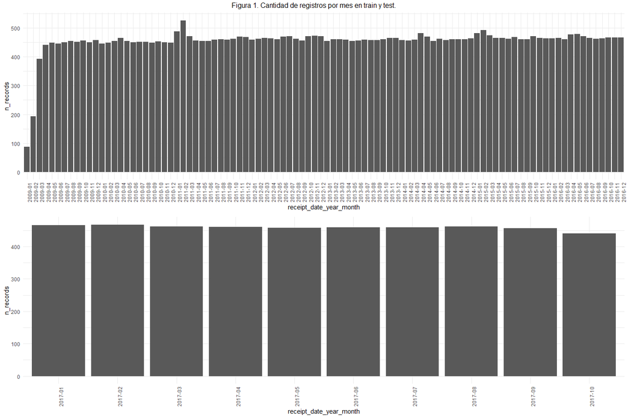

```r
grouped_train <- df_train %>%
  group_by(receipt_date_year_month) %>%
  summarise(
    n_records = n(),
    receipt_date_year_month = receipt_date_year_month
  ) %>%
  distinct(receipt_date_year_month,n_records)

grouped_test <- df_test %>%
  group_by(receipt_date_year_month) %>%
  summarise(
    n_records = n(),
    receipt_date_year_month = receipt_date_year_month
  ) %>%
  distinct(receipt_date_year_month,n_records)

plot1 <- ggplot(grouped_train, aes(x = receipt_date_year_month, y = n_records)) +
  geom_bar(stat = "identity") +
  theme_minimal() +
  theme(axis.text.x = element_text(angle = 90, hjust = 1))


plot2 <- ggplot(grouped_test, aes(x = receipt_date_year_month, y = n_records)) +
  geom_bar(stat = "identity") +
  theme_minimal() +
  theme(axis.text.x = element_text(angle = 90, hjust = 1))

grid.arrange(plot1, plot2,   top = "Figura 1. Cantidad de registros por mes en train y test.", nrow = 2)
```

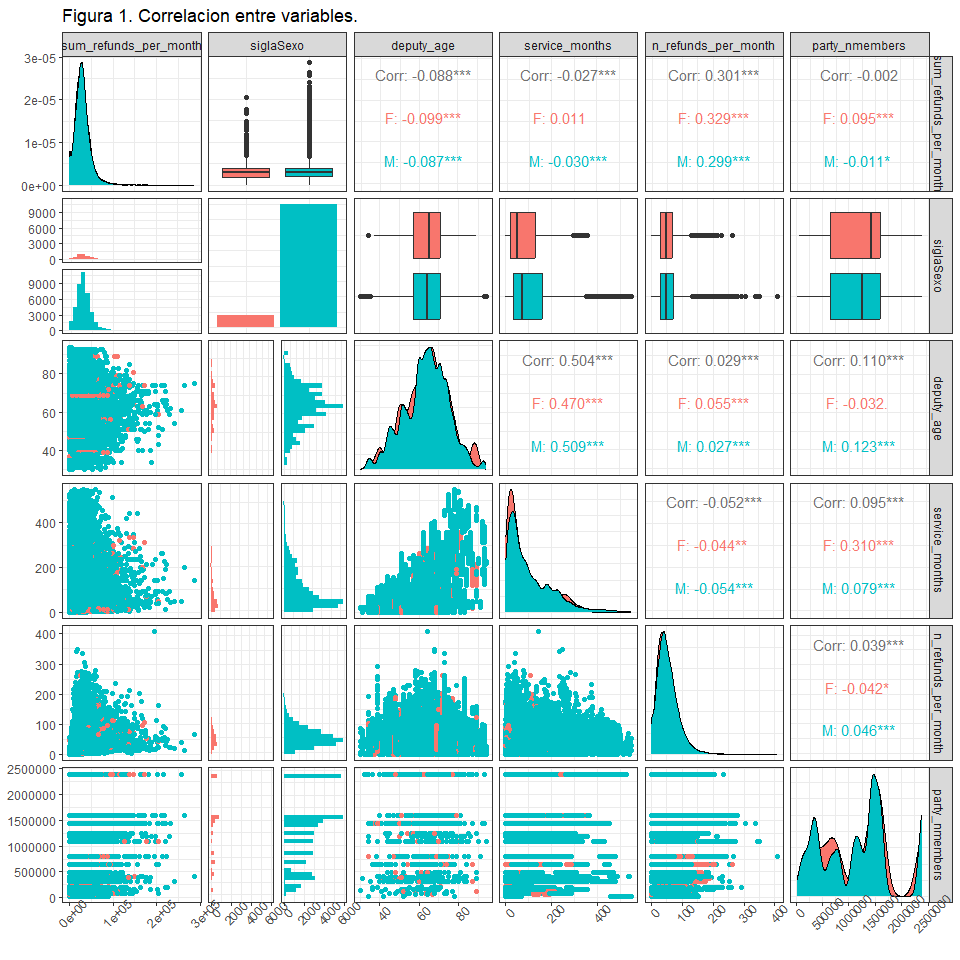

```r
cols <- c(
  "sum_refunds_per_month",
  "siglaSexo",
  "deputy_age",
  "service_months",
  "n_refunds_per_month",
  "party_nmembers"
)

df_target <- df_train[, cols]
#Graficamos
df_target %>%
  ggpairs(.,
          mapping = aes(colour = siglaSexo),
          title = "Figura 1. Correlacion entre variables.",
          upper = list(continuous = wrap("cor"))) +
  theme_bw() +
  theme(axis.text.x = element_text(angle=45), legend.position = "bottom")
```

```r
grouped <- df_all %>%
  group_by(political_party, party_nmembers) %>%
  summarise()


plot1 <- ggplot(df_all, aes(x = political_party, y = receipt_value)) +
  geom_boxplot() +
  theme_minimal() +
  theme(axis.text.x = element_text(angle = 90, hjust = 1))


plot2 <- ggplot(grouped, aes(x = political_party, y = party_nmembers)) +
  geom_bar(stat = "identity") +
  theme_minimal() +
  theme(axis.text.x = element_text(angle = 90, hjust = 1))

grid.arrange(plot1, plot2,   top = "Figura 2. Monto de reembolsos y cantidad de miembros por partidos", nrow = 2)
```

[output not shown]

```r
ggplot(df_all, aes(x = party_position, y = receipt_value)) +
  geom_boxplot() +
  theme_minimal() +
  labs(title = "Figura 3. Monto de los reembolsos respecto a la posicion politica del partido.")
```

[output not shown]

```r
ggplot(df_train, aes(x = party_position, y = sum_refunds_per_month)) +
  geom_boxplot() +
  theme_minimal() +
  labs(title = "Figura 4. Distribucion de los gastos mensuales")
```

[output not shown]

```r
grouped <- df_train %>%
  group_by(political_party, party_nmembers) %>%
  summarise()


plot1 <- ggplot(df_train, aes(x = political_party, y = sum_refunds_per_month)) +
  geom_boxplot() +
  theme_minimal() +
  theme(axis.text.x = element_text(angle = 90, hjust = 1))


plot2 <- ggplot(grouped, aes(x = political_party, y = party_nmembers)) +
  geom_bar(stat = "identity") +
  theme_minimal() +
  theme(axis.text.x = element_text(angle = 90, hjust = 1))

grid.arrange(plot1, plot2,   top = "Figura 5. Monto de reembolsos y cantidad de miembros por partidos", nrow = 2)
```

[output not shown]

# Construcción de modelos.

A partir de ahora, procederemos a crear, interpretar, evaluar y diagnosticar modelos de regresión. Los modelos considerados son el modelo lineal simple - que se utilizara como una especie de baseline - y el modelo de regresión múltiple y robusto. El objetivo de comparar los distintos modelos en términos de performance, y de como la elección del modelo afecta el cumplimiento de los supuestos que tienen que cumplir los modelos de regresión discutidos. Finalmente, aprovecharemos la ventaja explicativa de los modelos de regresión para tratar de entender que variables ayudan a predecir la suma de los reembolsos mensuales solicitados por los miembros de la Cámara de Brasil.

### Modelo lineal simple.

Para empezar con la construcción de modelos, primero ajustaremos un modelo lineal simple que usaremos como baseline para entender que tanto aportan los otros modelos que estamos considerando respecto al modelo simple, como se mencionó anteriormente. En este modelo, intentaremos calcular como varia la suma de las solicitudes mensuales de los reembolsos solicitados por los diputados respecto a la antigüedad (en meses) de los mismos.

```r
# Creamos el primer modelo lineal e imprimimos los coeficientes.
# GENERACION DE MODELOS: MODELO LINEAL SIMPLE                                  #
modelo_lineal = lm(formula = sum_refunds_per_month ~ service_months, data = df_train)
tidy(modelo_lineal)
```

[output not shown]

Observamos que la antigüedad (en meses) del diputado no tiene mucha relevancia a la hora de explicar la variabilidad del monto total de las solicitudes de reembolso mensuales por diputado dado que el coeficiente $R^2_{adj}$ es casi nulo. El intercepto $\hat{\beta_0}$ sugiere que un diputado recién iniciado en funciones hace solicitudes de reembolso mensuales por al menos unos 31721.2327 BRL en promedio (unos 9000 USD aproximadamente). La pendiente $\hat{\beta_1}$ sugiere que, con cada mes que pasa desde que iniciaron funciones los diputados, los montos de solicitudes de reembolso mensuales disminuyen -5.571 BRL en promedio, lo cual no es mucho. Si bien el p-valor de la pendiente es muy cercano a 0 y por lo tanto significativo, vemos que hacen falta otras variables explicativas para modelar el fenómeno de forma mas completa.

### Modelo lineal múltiple.

Procedemos a ajustar un modelo lineal múltiple con el objetivo de evaluar el cumplimiento de los supuestos usando la función de costo de mínimos cuadrados, y obtener las métricas de performance resultantes. Mas adelante haremos una comparación de estos resultados con los del modelo robusto. Las variables a elegir, junto con las razones por las cuales se escogió dicha variable, se describen a continuación:

No se tomó en consideración la variable sexo, porque no parecen haber diferencias significativas entre las solicitudes presentadas por diputados de distinto sexo.

```r
# Creamos el primer modelo lineal e imprimimos los coeficientes.
# GENERACION DE MODELOS: MODELO LINEAL MULTIPLE                                #
modelo_multiple = lm(formula = sum_refunds_per_month ~ n_refunds_per_month + party_position + party_nmembers + service_months + deputy_age, data=df_train)
tidy(modelo_multiple, conf.int = TRUE)
```

[output not shown]

Mas allá de la interpretación de los coeficientes, vemos que todas las variables explicativas elegidas para ajustar el modelo resultan significativas, dado que tienen p-valores por lo general muy cercanos a 0. Asimismo, en este modelo particular vemos que $R^2_{adj}$ = 0.1051, con lo cual podemos decir que el 10% de la variabilidad de la suma de los reembolsos por mes es explicada por el modelo, lo cual es bastante superior al modelo lineal generado inicialmente. Notamos que el valor del p-valor resultante de aplicar un test F-score es bastante cercano a 0, lo que nos indica que al menos una de las variables consideradas en el modelo resulta significativa.

#### Diagnóstico del modelo.

Dado que el modelo lineal múltiple sigue la siguiente expresión:
$$\hat{Y_i} = \hat{\beta_0} +
\hat{\beta_1}X_{i1} + \hat{\beta_1}X_{i2} + \cdots + \hat{\beta_k}X_{ik}
+ e_i,$$
Para decir que el ajuste resultante del modelo lineal es confiable, los residuos $e_i$ tienen que cumplir los siguientes supuestos:

- Los $\epsilon_i$ tiene media cero, $E (\epsilon_i) = 0.$
- Los $\epsilon_i$ tienen todos la misma varianza desconocida que llamaremos $\sigma^2$ y que es el otro parámetro del modelo. $Var (\epsilon_i) = \sigma^2$ (homocedasticidad).
- Los $\epsilon_i$ tienen distribución normal.
- Los $\epsilon_i$ son independientes entre sí, y son no correlacionados con las $X_i$

Para determinar si el modelo generado satisface estos supuestos, usaremos gráficos cruzados asociados a los residuos del modelo. En este caso, los residuos hacen referencia a la diferencia entre el valor observado y el valor predicho. Notamos que:

- El gráfico de los residuos vs los valores predichos (Residuals vs Fitted) muestra que la varianza parece mostrar una estructura bien definida: podríamos decir que hay un tramo en particular en el cual incrementa la varianza a medida que aumentan los valores predichos, y que parece haber una relación lineal entre los residuos y los valores ajustado. De aquí, podemos inferir que el supuesto de homogeneidad de varianzas (homoscedasticidad) no se satisface. Se observa algo similar en el gráfico de y Scale-Location.
- El gráfico de Normal Q-Q muestra que en los extremos los valores de los residuos estandarizados se alejan de forma significativa de la distribución teórica normal en especial para valores de cuantil teórico altos. De este comportamiento, podemos inferir que los residuos no cumplen el supuesto de normalidad.
- El gráfico de los residuos vs. la palanca (Residuals vs Leverage) muestra que hay varios de puntos con altos valores de residuos y varios puntos con alto leverage. Algo en particular que llama la atención es que existe una nube separada de puntos que tienen valores de alto leverage, y residuos estandarizados relativamente bajos. Estos puntos pueden estar influyendo en los coeficientes calculados por el modelo de regresión múltiple. La mayor distancia de Cook observada en los datos es de 0.01054, lo cual puede estar ocasionando que la curva de ajuste se desvíe hacia estos puntos de alto leverage.

```r
#distancias de Cook
cook_dist <- cooks.distance(modelo_multiple)
max(cook_dist)
#graficos de residuos
plot(modelo_multiple)
```

[output not shown]

Con estos gráficos concluimos que, al no cumplirse los supuestos de normalidad y homoscedasticidad, y al haber puntos de alto leverage, conviene aplicar un modelo de regresión robusto.

### Modelo robusto

Procedemos a aplicar el modelo robusto en el set de datos.

```r
# Creamos el primer modelo lineal e imprimimos los coeficientes.
# GENERACION DE MODELOS: MODELO LINEAL ROBUSTO                                 #
modelo_robusto_huber = MASS::rlm(
  formula = sum_refunds_per_month ~ n_refunds_per_month + party_position + service_months + deputy_age + party_nmembers,
  data=df_train,
  psi=psi.huber,
  method = "M",
  maxit=200
  )

tidy(modelo_robusto_huber, conf.int = TRUE)
```

[output not shown]

Para aplicar el modelo de regresión robusto, usamos la función $\texttt{rlm}$ del paquete $\texttt{MASS}.$ En este caso, la función de costo a optimizar es la función de costo de Huber. Vemos que los nuevos coeficientes tienen por lo general menor error y mayor precisión que los coeficientes generados por el modelo múltiple. Asimismo, los parámetros del modelo resultan ser bastante distintos a los del modelo múltiple, con lo cual podemos decir que en el primer caso, es posible que haya observaciones atípicas que ocasionaban una estimación errónea de los parámetros del modelo. Una de las cosas que más resalta es que la cantidad de miembros del partido ya no es una variable significativa para el modelo.

Las diferencias entre los dos modelos también se evalúan al usar los métodos gráficos para el diagnóstico del cumplimiento de supuestos del modelo. En primera instancia, vemos que los gráficos de Residuals vs Fitted y el gráfico de Normal Q-Q son bastante similares a los gráficos del modelo múltiple. No se cumplen los criterios de normalidad ni homoscedasticidad. Sin embargo, a diferencia del modelo de regresión múltiple, vemos que el gráfico de Residuals vs Leverage muestra que, si bien siguen habiendo puntos de alto leverage notablemente separados, ahora los residuos estandarizados parecen mostrar menor dispersión y ser más cercanos al 0. Asimismo, la curva de distancia de Cook (curva roja) también se mantiene bastante cercana al 0 para todos los valores de leverage graficados. Estas dos características evidenciadas en los gráficos parecen indicar que el modelo robusto, como se esperaba, le asigna un menor peso a las observaciones con altos residuos.

```r
plot(modelo_robusto)
```

[output not shown]

# Métricas de performance

#### Evaluación en train

```r
# evaluacion en train
# robusto
evaluacion_robusto = broom::augment(modelo_robusto_huber, df_train)

metricas_robusto_train = metrics(data = evaluacion_robusto, truth = sum_refunds_per_month, estimate = .fitted) %>%
  mutate(.estimate = round(.estimate, 4))

metricas_robusto_train$.metric <- paste0(metricas_robusto_train$.metric,"_robusto")

# evaluacion en train
# multiple
evaluacion_multiple = broom::augment(modelo_multiple, df_train)

metricas_multiple_train = metrics(data = evaluacion_multiple, truth = sum_refunds_per_month, estimate = .fitted) %>%
  mutate(.estimate = round(.estimate, 4))

metricas_multiple_train$.metric <- paste0(metricas_multiple_train$.metric,"_multiple")

resultado <- rbind(metricas_robusto_train, metricas_multiple_train) %>%
  arrange(.metric)

resultado
```

[output not shown]

Procedemos entonces a evaluar el modelo múltiple y el modelo robusto en el set de entrenamiento y el de validación. Las métricas a evaluar son $R^2,$ RMSE y el MAE. Se sabe que el error RMSE proporciona mayor peso a residuos grandes al calcular la raíz cuadrada del residuo al cuadrado. El RMSE es sensible a outliers y puede ser influenciado por valores atípicos. En cambio, la métrica MAE trata todos los residuos igual sin importar la magnitud del mismo. Es menos sensible a outliers y proporciona una alternativa mas robusta para evaluar accuracy cuando tratamos con datos con valores atípicos. De esta manera, parte de lo esperado es que los valores de MAE sean consistentemente menores que los de RMSE.

Al hacer la evaluación en el set de entrenamiento, notamos que la métrica de RMSE es un poco más alta para el modelo robusto. Esto es de esperar porque, al optimizar la función de costos de mínimos cuadrados, el modelo lineal múltiple ajusta los coeficientes para lograr minimizar el error cuadrático medio. Como vimos en los ejemplos anteriores, el modelo múltiple tiende estimar los coeficientes de manera tal que el modelo resultante queda lo mas cercano posible a los valores atípicos, con lo cual es esperable que el RMSE sea menor que el RMSE del modelo robusto.

Por otro lado, vemos que al evaluar en el set de entrenamiento, la métrica de MAE es menor para el modelo robusto. Esto ocurre porque, como se explicó anteriormente, MAE se presenta como una métrica de performance más robusta ante valores atípicos. Era de esperar que MAE fuera menor para el modelo robusto, ya que el mismo asigna menores pesos a residuos grandes cuando estima los coeficientes. Finalmente, en términos del $R^2,$ notamos que ambos modelos explican un 10% de la variabilidad del fenómeno aproximadamente, lo cual es una mejoría considerable respecto al modelo lineal simple.

#### Evaluación en test

```r
# evaluacion en test
# robusto
models <- list(
  modelo = modelo_robusto
)

lista_predicciones_testing = map(
  .x = models,
  .f = augment,
  newdata = df_test
)

metricas_robusto_test = lista_predicciones_testing$modelo %>%
  metrics(truth=sum_refunds_per_month, estimate=.fitted) %>%
  mutate(.estimate=round(.estimate, 4))

metricas_robusto_test$.metric <- paste0(metricas_robusto_test$.metric,"_robusto")

# evaluacion en test
# multiple
models <- list(
  modelo = modelo_multiple
)

lista_predicciones_testing = map(
  .x = models,
  .f = augment,
  newdata = df_test
)

metricas_multiple_test = lista_predicciones_testing$modelo %>%
  metrics(truth=sum_refunds_per_month, estimate=.fitted) %>%
  mutate(.estimate=round(.estimate, 4))

metricas_multiple_test$.metric <- paste0(metricas_multiple_test$.metric,"_multiple")


resultado <- rbind(metricas_multiple_test, metricas_robusto_test) %>%
  arrange(.metric)

resultado
```

[output not shown]

Posteriormente, evaluamos los modelos generados en el dataset de test. Notamos que, en general, la performance del modelo robusto es menor que la del modelo lineal múltiple; sin embargo, logra explicar mayor porcentaje de la variabilidad. Como se explicó anteriormente, esto es debido a que el modelo múltiple no penaliza residuos altos, con lo cual al hacer el ajuste, los valores atípicos tienden a atraer la curva de regresión, generando un menor residuo y por ende una menor métrica de error. Otra cosa que es de notar es que al evaluar en test, el valor de $R^2$ es mayor al observado en train. Esto nos dice que la variabilidad de los datos en el set de entrenamiento es mayor que la variabilidad de los datos en el set de test.

# Conclusiones

En términos interpretativos de los modelos realizados, vemos que si existe una influencia significativa entre características inherentes a los partidos políticos, características personales del diputado y la cantidad de reembolsos solicitados por cada diputado mensualmente, siendo la covariable mas influyente la ideología asociada al partido político. Sería interesante en estudios futuros, también incluir otros datos como la formación profesional, si el diputado viene de una familia bien acomodada, entre otros factores que puedan ayudar a modelar los consumos mensuales.

En términos de los modelos utilizados, vemos que es conveniente utilizar el modelo robusto en presencia de outliers cuando sabemos que el dataset a analizar contiene outliers. El no usarlo, puede ocasionar interpretaciones y predicciones erróneas del modelo generado.